# R 資料操作入門

Week 02 · IMS 2e Tutorial 1 · Posit Cloud  
回到 Week 02 Index

HT3001B 生物統計學與 R

## 今天會完成什麼？

在 Posit Cloud 的同一個 RStudio Project 中：

1. 建立並保存 R Script。
2. 載入套件與教材資料。
3. 將資料寫成 CSV，再從 Project 讀回。
4. 查看、選取、篩選及新增欄位。
5. 使用管線串接資料操作。
6. 用 `ggplot2` 畫出基本圖形。

今天的重點是操作 R：寫下程式、執行、查看結果，再保存可重新執行的版本。

[IMS Tutorial 1: Introduction to data](https://openintrostat.github.io/ims-tutorials/01-data/) · [Posit Cloud: Code Projects](https://docs.posit.co/cloud/guide/projects/)

## 本課的工作平台：Posit Cloud

1. 登入 [posit.cloud](https://posit.cloud/)。
2. 進入自己的 **Your Workspace**。
3. 選擇 **New Project → New RStudio Project**，自行建立專案。
4. 將專案命名為 `HT3001B_week02`。

所有程式、資料與輸出都保存在雲端專案；本課不需要在個人電腦安裝 R 或 RStudio。

[Posit Cloud: RStudio Projects](https://docs.posit.co/cloud/guide/projects/#rstudio-projects) · 課程 syllabus_v3「R 與軟體環境」

## 先保存一份可以重跑的程式

在 RStudio 中選擇 **File → New File → R Script**，儲存為：

```
week02_tutorial.R
```

今天使用的程式依序貼入這個檔案，再用：

- Windows：`Ctrl + Enter`
- macOS：`Cmd + Enter`
- 或按編輯區上方的 **Run**

先存檔再執行；重新登入時，從 **Files** 開啟同一份程式。

[Posit Cloud: Code Projects](https://docs.posit.co/cloud/guide/projects/) · 課程 Posit Cloud 帳號建立指引

## RStudio 四個區域各做什麼？

| 區域 | 今天的用途 |
| --- | --- |
| Source | 撰寫與保存`week02_tutorial.R` |
| Console | 顯示執行結果與錯誤訊息 |
| Environment | 查看目前建立的資料與物件 |
| Files／Plots／Help | 管理檔案、看圖、查函數說明 |

把程式寫在 Source；Console 是執行現場，不是主要筆記本。

[Posit Cloud: RStudio Projects](https://docs.posit.co/cloud/guide/projects/#rstudio-projects)

## 先執行三行 R

```r
1 + 1

course_name <- "HT3001B"
course_name
```

- `<-` 把右側的值指定（assignment）給左側名稱。
- 保存的名稱與內容合稱物件（object）。
- 只輸入物件名稱，R 會顯示目前保存的值。
- Console 開頭的 `>` 是提示符號，不需要輸入。

IMS Tutorial 1 · Lesson 1: Language of data · Posit Cloud 操作改編

## 操作例子：建立物件後再使用

```r
quiz_scores <- c(72, 85, 91)

quiz_scores
length(quiz_scores)
quiz_scores + 5
```

依序觀察：

1. `quiz_scores` 保存三個數值。
2. `length()` 回傳物件中的元素個數。
3. `+ 5` 會對每個數值進行相同運算。

先執行建立物件的程式，再執行使用物件的程式。

IMS Tutorial 1 · Lesson 1: Language of data · 自編操作例子

## 套件：安裝一次，每次工作階段載入

若 Console 顯示某套件尚未安裝，先執行一次：

```r
install.packages(c("tidyverse", "openintro"))
```

每次重新開啟 R 工作階段，再執行：

```r
library(tidyverse)
library(openintro)
```

`install.packages()` 把套件（package）加入專案環境；`library()` 讓本次工作階段使用套件。

IMS Tutorial 1 · Lesson 1: Packages

## 操作例子：確認套件與資料可以使用

```r
library(openintro)
class(hsb2)
head(hsb2, n = 3)
```

執行後確認：

- `class(hsb2)` 顯示資料物件的類別。
- `head(..., n = 3)` 只顯示前三列。
- 若找不到 `hsb2`，先確認 `library(openintro)` 是否已成功執行。

載入套件後，立即用一個簡短指令確認資料是否可用。

IMS Tutorial 1 · Lesson 1: Packages／Data in R · 自編操作例子

## 檔案存取從 Project 根目錄開始

今天使用相對路徑（relative path）：

```
HT3001B_week02/
├─ week02_tutorial.R
└─ data/
   └─ hsb2.csv
```

程式中的路徑寫成：

```r
"data/hsb2.csv"
```

相對路徑以目前的 RStudio Project 為起點，不需要貼入個人電腦的完整路徑。

[Posit Cloud: Code Projects](https://docs.posit.co/cloud/guide/projects/) · 課程 Posit Cloud 檔案結構

## 第一步：將 `hsb2` 寫成 CSV

```r
dir.create("data", showWarnings = FALSE)

write_csv(
  hsb2,
  "data/hsb2.csv"
)

file.exists("data/hsb2.csv")
```

- `dir.create()` 建立 `data` 資料夾。
- `write_csv()` 將資料框寫入檔案。
- `file.exists()` 應回傳 `TRUE`。

[readr: `write_csv()`](https://readr.tidyverse.org/reference/write_delim.html) · Posit Cloud 操作改編

## 第二步：從 CSV 讀回資料

```r
hsb2_from_file <- read_csv(
  "data/hsb2.csv"
)

glimpse(hsb2_from_file)
```

讀程式時分成三步：

1. 找到 `data/hsb2.csv`。
2. `read_csv()` 讀取檔案並判斷各欄型態。
3. 將結果指定給新物件 `hsb2_from_file`。

[readr: `read_csv()`](https://readr.tidyverse.org/reference/read_delim.html) · Posit Cloud 操作改編

## 第三步：核對寫出與讀回的結果

```r
dim(hsb2)
dim(hsb2_from_file)

names(hsb2)
names(hsb2_from_file)
```

核對兩件事：

- 列數與欄數是否相同。
- 欄位名稱與順序是否相同。

CSV 保存表格中的值；重新讀入時，R 會重新判斷欄位型態，因此還要用 `glimpse()` 查看結構。

[readr: `write_csv()`](https://readr.tidyverse.org/reference/write_delim.html) · [readr: `read_csv()`](https://readr.tidyverse.org/reference/read_delim.html)

## 練習：用新檔名完成一次來回

```r
write_csv(
  hsb2,
  "data/hsb2_copy.csv"
)

hsb2_copy <- read_csv(
  "data/hsb2_copy.csv"
)

file.exists("data/hsb2_copy.csv")
glimpse(hsb2_copy)
```

完成後，在 **Files → data** 找到 `hsb2_copy.csv`。

readr 檔案讀寫 · 自編 Posit Cloud 操作練習

## 載入後，先看資料框的結構

```r
library(tidyverse)
library(openintro)

glimpse(hsb2)
```

`glimpse()` 會顯示：

- 資料框（data frame）有幾列、幾欄。
- 每個欄位的名稱與 R 儲存型態。
- 各欄前幾個值。

先看結構，再決定下一個資料操作。

IMS Tutorial 1 · Lesson 1: Data in R／Take a peek · `openintro::hsb2`

## 用三個函數快速查看資料

```r
dim(hsb2)
names(hsb2)
head(hsb2)
?hsb2
```

| 函數 | 顯示內容 |
| --- | --- |
| `dim()` | 列數與欄數 |
| `names()` | 所有欄位名稱 |
| `head()` | 前幾列資料 |
| `?hsb2` | 查看hsb2說明 |

不知道欄位名稱時，先執行 `names()` 或 `glimpse()`，不要靠猜測。

IMS Tutorial 1 · Lesson 1: Data in R／Take a peek · 函數操作整理

## 操作例子：控制要查看的資料列數

```r
head(hsb2, n = 2)
head(hsb2, n = 5)
```

比較兩次輸出：

- 資料內容沒有改變。
- `n` 決定要顯示前幾列。
- 函數的引數（argument）可以改變執行方式。

修改一個引數、重新執行，再比較輸出有何不同。

IMS Tutorial 1 · Lesson 1: Data in R／Take a peek · 自編操作例子

## `select()`：只顯示需要的欄位

```r
hsb2 |>
  select(id, read, write, math)
```

也可以排除欄位：

```r
hsb2 |>
  select(-id)
```

`select()` 改變顯示或保留的欄，不會自行修改原本的 `hsb2`。

IMS Tutorial 1 · Lesson 1: Variables in `hsb2` · `dplyr::select()`

## 操作例子：保存選出的欄位

```r
hsb2_scores <- hsb2 |>
  select(id, read, write, math)

names(hsb2_scores)
head(hsb2_scores, n = 3)
```

執行後在 Environment 找到 `hsb2_scores`，再確認它只包含四個指定欄位。

把結果指定給新名稱，後續程式就能直接使用精簡後的資料框。

IMS Tutorial 1 · Lesson 1: Variables in `hsb2` · `dplyr::select()` · 自編操作例子

## `filter()`：保留符合條件的列

```r
hsb2_public <- hsb2 |>
  filter(schtyp == "public")

glimpse(hsb2_public)
```

常用條件符號：

- `==`：等於
- `!=`：不等於
- `>`、`>=`、`<`、`<=`：大小比較

IMS Tutorial 1 · Lesson 1: Filtering based on a factor · `dplyr::filter()`

## 操作例子：修改篩選條件

```r
hsb2_read60 <- hsb2 |>
  filter(read >= 60)

head(hsb2_read60, n = 3)
nrow(hsb2_read60)
```

接著把 `60` 改成 `70`，重新執行並比較 `nrow()` 的結果。

`filter()` 保留符合條件的資料列；條件改變，保留的列數也可能改變。

IMS Tutorial 1 · Lesson 1: Filtering data · `dplyr::filter()` · 自編操作例子

## `count()`：計算每個值出現幾次

```r
hsb2 |>
  count(schtyp)
```

兩個欄位一起計數：

```r
hsb2 |>
  count(schtyp, prog)
```

輸出中的 `n` 是每種組合所包含的資料列數。

IMS Tutorial 1 · Lesson 1: Categorical data in R · `dplyr::count()`

## 操作例子：依出現次數排序

```r
hsb2 |>
  count(prog, sort = TRUE)
```

再比較未排序的版本：

```r
hsb2 |>
  count(prog)
```

`sort = TRUE` 只改變輸出的排列順序，不改變各類別的計數。

IMS Tutorial 1 · Lesson 1: Categorical data in R · `dplyr::count()` · 自編操作例子

## 兩種管線（pipe）寫法

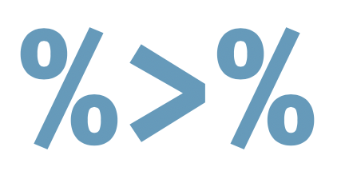

```r
hsb2 %>%
  count(schtyp)
```

[figure not shown]

```r
hsb2 |>
  count(schtyp)
```

原教程同時出現 `%>%` 與 `|>`；本課範例統一使用 R 原生 pipe `|>`。

IMS Tutorial 1 · Lesson 1: The pipe operator · 原圖 `pipe-operator.png`、`native_pipe-operator.png`

## pipe 讓程式依執行順序閱讀

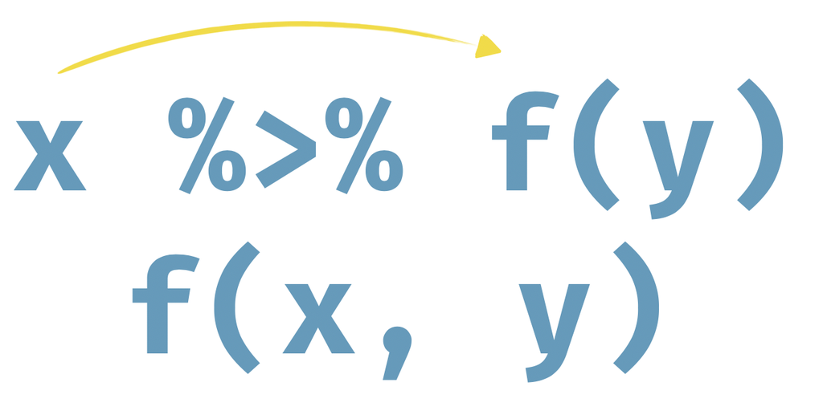

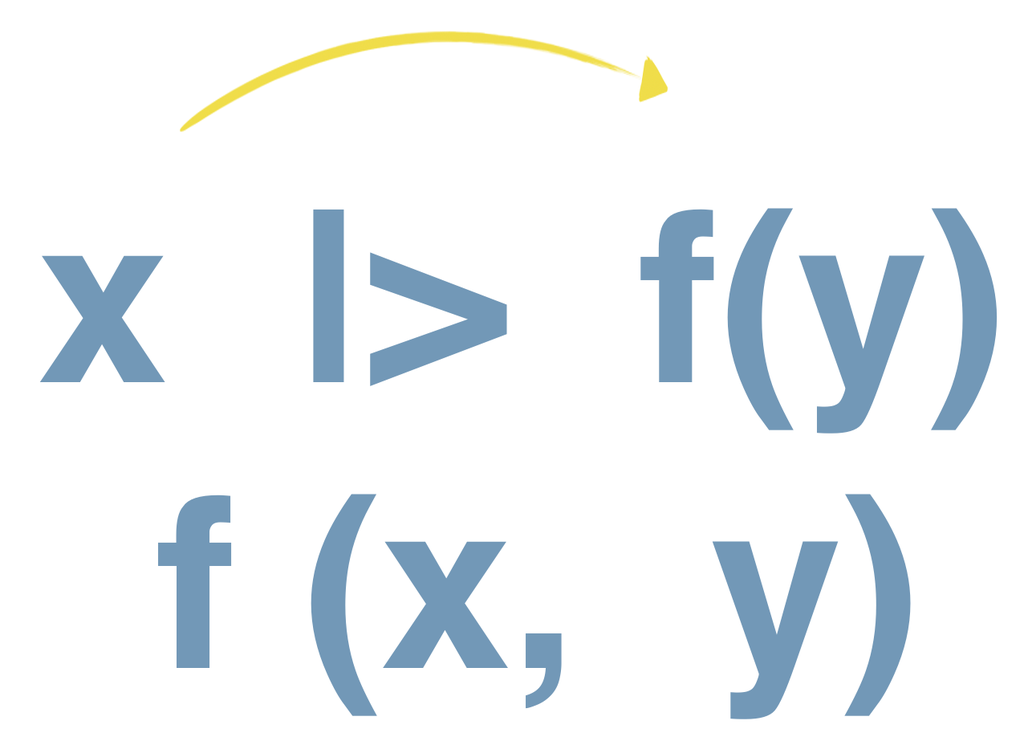

```r
hsb2 |>
  filter(schtyp == "public") |>
  count(prog)
```

讀法：從 `hsb2` 開始，先篩選，再計數。

IMS Tutorial 1 · Lesson 1: The pipe operator · 原圖 `pipe-operator2.png`、`native_pipe-operator2.png`

## 操作例子：用 pipe 串接三個步驟

```r
hsb2 |>
  filter(read >= 60) |>
  select(id, read, write) |>
  head(n = 5)
```

由上往下讀：

1. 保留 `read >= 60` 的列。
2. 保留三個欄位。
3. 顯示前五列結果。

每一行接收上一行的結果，再完成下一個操作。

IMS Tutorial 1 · Lesson 1: The pipe operator · 自編操作例子

## 指定結果，避免覆寫原始資料

```r
hsb2_public <- hsb2 |>
  filter(schtyp == "public")
```

現在 Environment 中有兩個物件：

- `hsb2`：原始資料框。
- `hsb2_public`：篩選後的新資料框。

練習時先建立新物件；確認結果正確後，再決定是否覆寫原始名稱。

IMS Tutorial 1 · Lesson 1: Filtering based on a factor · 指定操作整理

## 操作例子：比較原始物件與新物件

```r
dim(hsb2)
dim(hsb2_public)

names(hsb2)
names(hsb2_public)
```

比較輸出時注意：

- 篩選後的列數可能不同。
- 欄位名稱仍然相同。
- 原始物件 `hsb2` 仍保留在 Environment。

IMS Tutorial 1 · Lesson 1: Filtering based on a factor · 自編操作例子

## `mutate()`：新增欄位

```r
avg_read <- mean(hsb2$read)

hsb2_updated <- hsb2 |>
  mutate(
    read_cat = if_else(
      read < avg_read,
      "below average",
      "at or above average"
    )
  )
```

`mutate()` 建立或修改欄位；`if_else()` 依條件填入兩種結果。

IMS Tutorial 1 · Lesson 1: Discretize variables／New variable `read_cat`

## 操作例子：檢查新增欄位

```r
hsb2_updated |>
  select(id, read, read_cat) |>
  head(n = 6)

hsb2_updated |>
  count(read_cat)
```

第一段逐列查看原值與新類別；第二段確認每個新類別有幾列。

新增欄位後，先查看部分資料，再計數確認結果。

IMS Tutorial 1 · Lesson 1: New variable `read_cat` · 自編操作例子

## 新欄位與原欄位可以並存

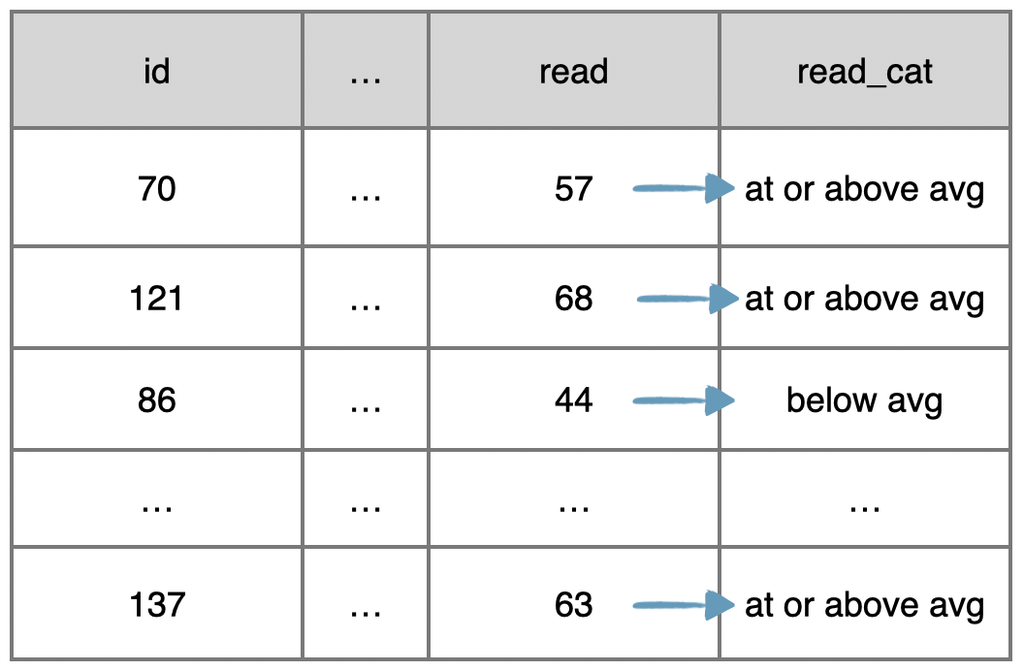

`read` 仍保留；`read_cat` 是程式新增的欄位。

用新名稱保存結果，方便比較轉換前後的資料。

IMS Tutorial 1 · Lesson 1 · 原圖 `new-variable-read-cat.png`

## 練習：完成 `if_else()`

```r
med_num_char <- median(email50$num_char)

email50_updated <- email50 |>
  mutate(
    num_char_cat = if_else(
      num_char < med_num_char,
      ___,
      ___
    )
  )

email50_updated |>
  count(num_char_cat)
```

依序填入 `"below median"` 與 `"at or above median"`，再執行 `count()` 查看新欄位。

IMS Tutorial 1 · Lesson 1: New variable `num_char_cat` · 教材練習改編

## 合併文字類別，再畫次數圖

```r
email50_updated <- email50 |>
  mutate(
    number_cat = if_else(
      number == "none",
      "no",
      "yes"
    )
  )

ggplot(email50_updated, aes(x = number_cat)) +
  geom_bar()
```

`aes(x = number_cat)` 指定橫軸欄位；`geom_bar()` 計算並畫出各值的筆數。

IMS Tutorial 1 · Lesson 1: Combining levels of a factor

## 綜合練習資料：`evals`

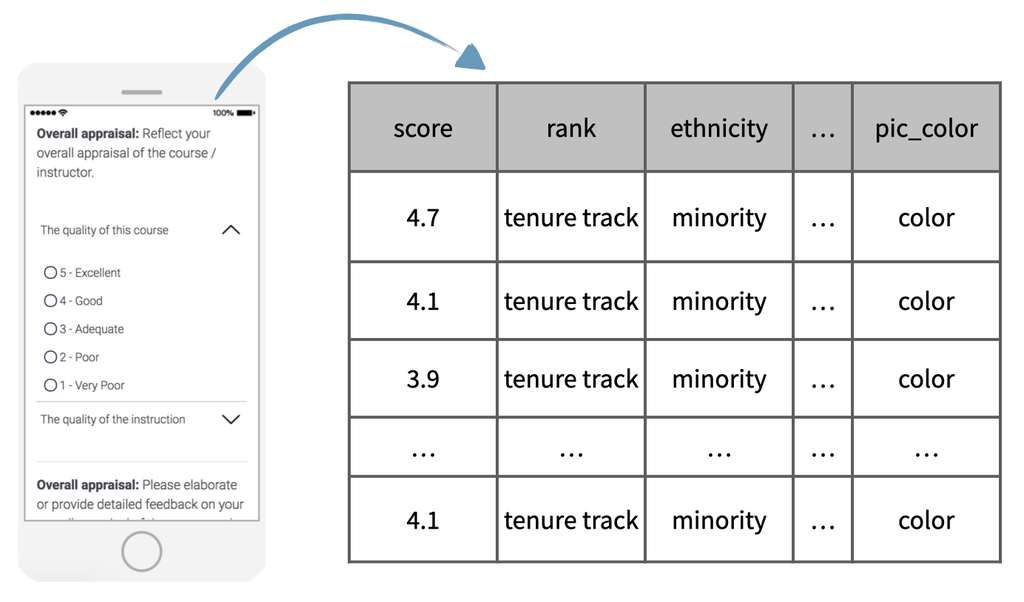

`evals` 是 `openintro` 套件中的資料框，可用來練習查看、轉換與畫圖。

IMS Tutorial 1 · Lesson 4: Beauty in the classroom · 原圖 `evals-data.png`

## 查看 `evals`，再選出練習欄位

```r
glimpse(evals)

evals_small <- evals |>
  select(
    score,
    rank,
    age,
    cls_students,
    bty_avg
  )

glimpse(evals_small)
```

先確認欄位名稱，再把需要的欄位保存成新的資料框。

IMS Tutorial 1 · Lesson 4: Inspect the data／Variables in the data

## `case_when()`：處理三個以上條件

```r
evals_updated <- evals |>
  mutate(
    cls_type = case_when(
      cls_students <= 18 ~ "small",
      cls_students >= 19 & cls_students <= 59 ~ "midsize",
      cls_students >= 60 ~ "large"
    )
  )
```

每一行以「條件 `~` 結果」表示；R 由上往下檢查條件。

IMS Tutorial 1 · Lesson 4: Recode a variable

## 操作例子：確認三類結果

```r
evals_updated |>
  select(cls_students, cls_type) |>
  arrange(cls_students) |>
  head(n = 8)

evals_updated |>
  count(cls_type)
```

先依原欄位排序查看分類邊界，再用 `count()` 檢查各類別。

IMS Tutorial 1 · Lesson 4: Recode a variable · 自編操作例子

## `ggplot()`：先指定資料與座標

```r
ggplot(
  evals_updated,
  aes(x = bty_avg, y = score)
) +
  geom_point()
```

讀程式時分成三層：

1. `evals_updated`：使用哪份資料。
2. `aes()`：哪些欄位對應到圖形屬性。
3. `geom_point()`：用點呈現每列資料。

IMS Tutorial 1 · Lesson 4: Create a scatterplot

## 在 `aes()` 中加入顏色對應

```r
ggplot(
  evals_updated,
  aes(
    x = bty_avg,
    y = score,
    color = cls_type
  )
) +
  geom_point()
```

把 `color = cls_type` 放在 `aes()` 中，R 會依欄位值建立顏色與圖例。

IMS Tutorial 1 · Lesson 4: Create a scatterplot, with an added layer

## 操作例子：調整點與圖形標籤

```r
ggplot(
  evals_updated,
  aes(x = bty_avg, y = score, color = cls_type)
) +
  geom_point(alpha = 0.6, size = 2) +
  labs(
    x = "Average beauty rating",
    y = "Course evaluation score",
    color = "Class size"
  )
```

`geom_point()` 調整點的呈現；`labs()` 修改座標軸與圖例標籤。

IMS Tutorial 1 · Lesson 4: Create a scatterplot · `ggplot2` 操作延伸

## 練習：修改圖形對應

從下列程式開始：

```r
ggplot(
  evals_updated,
  aes(x = age, y = score)
) +
  geom_point()
```

試著完成兩次修改：

1. 將橫軸換成 `cls_students`。
2. 在 `aes()` 加入 `color = rank`。

一次只改一處，重新執行並觀察圖形哪個部分改變。

IMS Tutorial 1 · Lesson 4 · `ggplot2` 操作練習改編

## 一段資料操作的閱讀順序

```r
result <- evals |>
  select(score, rank, cls_students) |>
  filter(cls_students >= 20) |>
  mutate(score_100 = score * 20)
```

1. 從 `evals` 開始。
2. 保留三個欄位。
3. 保留 `cls_students >= 20` 的列。
4. 新增 `score_100`。
5. 將最後結果指定給 `result`。

IMS Tutorial 1 · Lesson 1 · `dplyr` 操作整合

## 在 Posit Cloud 保存今天的成果

離開前確認：

- `week02_tutorial.R` 已保存。
- 從第一行重新執行時，必要套件可載入。
- Environment 中可看到自己建立的資料框。
- Plots 面板中的圖可以由程式重新產生。
- 重新登入同一個帳號與 Project 後，仍找得到程式檔。

不要只保存畫面截圖；保存能重新產生結果的程式。

[Posit Cloud: Code Projects](https://docs.posit.co/cloud/guide/projects/) · IMS Tutorial 1 · Posit Cloud 操作改編

## 遇到錯誤時，先讀 Console

| 訊息或現象 | 先確認 |
| --- | --- |
| `there is no package called ...` | 是否先執行`install.packages()` |
| `could not find function ...` | 是否用`library()` 載入套件 |
| `object ... not found` | 建立物件的前一段程式是否已執行 |
| 出現`+` 而不是 `>` | 括號或引號可能尚未關閉；按 Esc 後重試 |
| 找不到檔案 | 是否登入正確帳號、開啟正確 Project |

回報問題時，保留完整錯誤訊息與出錯程式；不要只寫「不能跑」。

IMS Tutorial 1 · Posit Cloud 專案操作 · 課程常見錯誤整理

## 課後練習與來源

- IMS 2e · Ch. 3 Applications: Data
- [Tutorial 1: Introduction to data](https://openintrostat.github.io/ims-tutorials/01-data/)
- [Lesson 1: Language of data](https://openintro.shinyapps.io/ims-01-data-01/)
- [Lesson 4: Case study](https://openintro.shinyapps.io/ims-01-data-04/)
- [教程原始碼與圖示](https://github.com/OpenIntroStat/ims-tutorials/tree/main/01-data)
- [Posit Cloud: Code Projects](https://docs.posit.co/cloud/guide/projects/)

課後從空白 R Script 開始，依序重做載入、查看、選欄、篩選、新增欄位與畫圖。

IMS 2e §3.3 Interactive R tutorials · IMS Tutorial 1 · Posit Cloud Documentation

## 加入R Slido

[figure not shown]

R Slido 單元的 QR code，活動代碼 3204727

掃描 QR code，或[點此加入R Slido](https://app.sli.do/event/mYJsjv2RF7ixtDGMcWRc39/live/polls)。

也可至 slido.com 輸入代碼 **3204727**。

- 三題皆為單選 Quiz：每題 **45 秒**。
- 進入後，等待題目開放。

HT3001B · Week 02 · R Slido · 活動日期：2026-09-16–2026-09-18

## Slido 1

[前往 Slido Quiz 作答](https://app.sli.do/event/mYJsjv2RF7ixtDGMcWRc39/embed/polls/a587c5ff-5c56-42a1-8739-1c260a61854b)

## Slido 2

[前往 Slido Quiz 作答](https://app.sli.do/event/mYJsjv2RF7ixtDGMcWRc39/embed/polls/a587c5ff-5c56-42a1-8739-1c260a61854b)

## Slido 3

[前往 Slido Quiz 作答](https://app.sli.do/event/mYJsjv2RF7ixtDGMcWRc39/embed/polls/a587c5ff-5c56-42a1-8739-1c260a61854b)